# QuickStart for GOVS

GOVS package, Version 1.0

## Contents

1. Package installation
2. Data preparation
   1. Genotypic data
   2. Phenotypic data
   3. Bins data
   4. Bins information data
3. Genome Optimization via Virtual Simulation
4. rrBLUP for Genotype-to-phenotype prediciton
5. Construct bin map
6. Visualization of bin
   1. Plot bin map
   2. Plot mosaic plot

This vignette briefly introduces some typical examples of GOVS to help users get started quickly. Detailes and other functions of GOVS,please see [Tutorial for GOVS](https://govs-pack.github.io/Tutorial/) or [Reference Manual](https://github.com/GOVS-pack/GOVS/blob/master/GOVS-Reference-Manual.pdf).

**Homepage**: https://govs-pack.github.io/

**Github repository**: https://github.com/GOVS-pack/GOVS

## How to install GOVS

#### 1. Github install

```r
## install dependencies and GOVS
install.packages(c("ggplot2","rrBLUP","lsmeans","readr","pbapply","pheatmap","emmeas"))
require("devtools")
install_github("GOVS-pack/GOVS")
## if you want build vignette in GOVS
install_github("GOVS-pack/GOVS",build_vignettes = TRUE)
```

#### 2. Download .tar.gz package and install

Download link: https://github.com/GOVS-pack/GOVS/raw/master/GOVS_1.0.tar.gz

```r
## install dependencies and GOVS with bult-in vignette
install.packages(c("ggplot2","rrBLUP","lsmeans","readr","pbapply","pheatmap","emmeas"))
install.packages("DownloadPath/GOVS_1.0.tar.gz")
```

#### Library GOVS

```r
library("GOVS")
```

Back to Contents

## Input data for GOVS

#### Genotypic data (hapmap format, matrix)

SNP rs must coded with pattern "chr[0-9].s/_[0-9]*" (eg: chr1.s_4831, “1” for chromosome, “4831” for locus).

```r
data(MZ)
MZ[1:10,1:15]
```

```
#>       V1               V2    V3  V4        V5  V6  V7  V8  V9  V10 V11
#>  [1,] "chr1.s_4817"    "C/G" "1" "4817"    "+" "-" "-" "-" "-" "-" "Reseq"
#>  [2,] "chr1.s_980088"  "A/C" "1" "980088"  "+" "-" "-" "-" "-" "-" "Reseq"
#>  [3,] "chr1.s_982448"  "G/A" "1" "982448"  "+" "-" "-" "-" "-" "-" "Reseq"
#>  [4,] "chr1.s_1105899" "A/G" "1" "1105899" "+" "-" "-" "-" "-" "-" "Reseq"
#>  [5,] "chr1.s_1781859" "C/T" "1" "1781859" "+" "-" "-" "-" "-" "-" "Reseq"
#>  [6,] "chr1.s_1782597" "A/C" "1" "1782597" "+" "-" "-" "-" "-" "-" "Reseq"
#>  [7,] "chr1.s_1785099" "A/G" "1" "1785099" "+" "-" "-" "-" "-" "-" "Reseq"
#>  [8,] "chr1.s_2688337" "T/C" "1" "2688337" "+" "-" "-" "-" "-" "-" "Reseq"
#>  [9,] "chr1.s_2691433" "C/G" "1" "2691433" "+" "-" "-" "-" "-" "-" "Reseq"
#> [10,] "chr1.s_2734450" "G/C" "1" "2734450" "+" "-" "-" "-" "-" "-" "Reseq"
#>       MG1265 MG1188 MG1189 MG1190
#>  [1,] "CG"   "CC"   "CC"   "CC"
#>  [2,] "AA"   "AA"   "AA"   "AC"
#>  [3,] "AA"   "GA"   "AA"   "AA"
#>  [4,] "AA"   "AG"   "AA"   "AA"
#>  [5,] "CC"   "CT"   "CC"   "CC"
#>  [6,] "AA"   "AA"   "AC"   "AA"
#>  [7,] "AA"   "AG"   "AA"   "AG"
#>  [8,] "TT"   "TT"   "TT"   "TT"
#>  [9,] "GG"   "CG"   "GG"   "GG"
#> [10,] "CC"   "GC"   "CC"   "CC"
```

#### Phenotypic data

Phenotypic data (dataframe), first column is lines ID.

```r
data(phe)
head(phe)
```

```
#>     line      DTT       PH       EW         seqname
#> 1 MG1265 61.86433 271.7185 230.2414 MG1265-x-MG1522
#> 2 MG1188 62.02350 248.8593 237.0546 MG1188-x-MG1522
#> 3 MG1189       NA       NA       NA MG1189-x-MG1522
#> 4 MG1190 61.70517 260.9880 225.2397 MG1190-x-MG1522
#> 5 MG1191 62.18266 264.2650 229.6803 MG1191-x-MG1522
#> 6 MG1192 60.75018 275.9395 228.0318 MG1192-x-MG1522
```

#### Bins data

Bins data (matrix), each row represents a bin (reconbination fragment) and each column represents a progeny, contents represent the origins of the bins tracing back to the parental lines.

```r
data(bins)
bins[1:5,1:5]
```

```
#>    MG100 MG1000 MG1001 MG1002 MG1003
#> 2     22     23      7     22     19
#> 7     22     23      7     16     19
#> 8     22     23      7     16     19
#> 14    22     23      7     16     19
#> 40    22     23      7      4     19
```

#### Bins information data

Bins information data (dataframe) corresponding to bins data, consists of five columns (bin ID, chromsome, start position, end position and length of each bin).

```r
data("binsInfo")
head(binsInfo)
```

```
#>   bin chr      sta1      end1     len1
#> 1   2   1    2350.5  259449.5 257099.0
#> 2   7   1  833073.0  991203.0 158130.0
#> 3   8   1  991203.0 1179517.5 188314.5
#> 4  14   1 1756883.5 1792781.5  35898.0
#> 5  40   1 2688264.5 2729192.0  40927.5
#> 6  42   1 2733711.5 2737865.0   4153.5
```

###### **NOTE: The header of bins, the first column of phenotype and the header of genotype must be unified, we recommend unify these ID with patrental ID.**

Back to Contents

## Run GOVS

```r
GOVS_res <- GOVS(MZ,pheno = phe,trait = "EW",which = "max",bins = bins,
                 binsInfo = binsInfo,module = "DES")
```

#### Output of GOVS:

###### A list containing the following elements (if `output = NULL`, default NULL) or several files with same prefix (if `output` is defined).

- `$GORes` Genome optimization results.
- `$virtualGenome` A matrix involves of three optimal virtual genomes.
- `$statRes` A data frame regarding statistics results of virtual simulation.
  - `Lines` Lines
  - `Bins(#)` The number (#) of bins that a line contributed to the simulated genome.
  - `Bins(%)` The number of bins that a line contributed accounting for the proportion (%) of simulated genome.
  - `Fragments(%)` The total length of genomic fragments that a line contributed accounting for the proportion (%) of simulated genome.
  - `phenotype` The phenotypic value of the corresponding lines or their offspring.
  - `phenotypeRank` The phenotype rank.
  - `Cumulative(%)` The cumulative percentage of fragments contributing to the simulated genome.

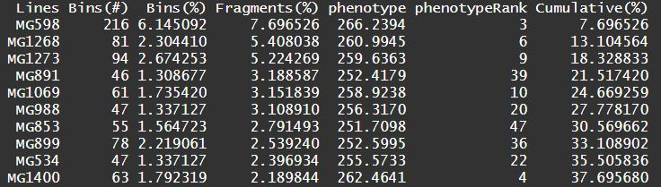

```r
GOVS_res$statRes
```

Figure1 Statistic summary of GOVS

## Genotytpe-to-phenotype prediciton (rrBLUP)

This function performs genotpye-to-phenotype prediciton via ridge regression best linear unbiased prediction (rrBLUP) model (Endelman, 2011). The inputs is genotypeic data.

```r
## load hapmap data (genomic data) of MZ hybrids
data(MZ)
## load phenotypic data of MZ hybrids
data(phe)
## pre-process for G2P prediction
rownames(MZ) <- MZ[,1]
MZ <- MZ[,-c(1:11)]
MZ.t <- t(MZ)
## conversion
MZ.n <- transHapmap2numeric(MZ.t)
dim(MZ.t)
```

```
#> [1] 1404 4903
## prediction
```

```r
idx1 <- sample(1:1404,1000)
idx2 <- setdiff(1:1404,idx1)
predRes <- SNPrrBLUP(MZ.n,phe$EW,idx1,idx2,fix = NULL,model = FALSE)

head(predRes)
```

```
#>   MG1194   MG1200   MG1201   MG1209   MG1210   MG1212
#> 236.2447 222.0445 224.5964 237.4851 225.4299 216.4166
```

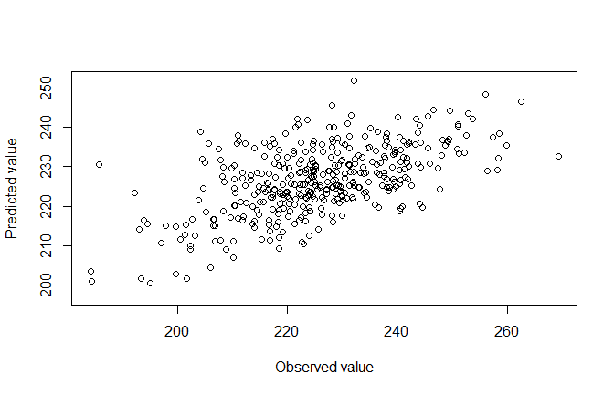

```r
## scatter plot
plot(phe$EW[idx2],predRes,xlab = "Observed value", ylab =  "Predicted value")
```

Figure2 Observed value VS predicted value

Back to Contents

## Construct bin map

IBD map was constructed of contributions from the parents onto the progeny lines discribed by Liu **et al.** (Liu *et al.*, 2020) based hidden Markov model (HMM) (Mott *et al*, 2000). Here we take chromosome-10 of one offspring as an example.

```r
## load example data
data(IBDTestData)

## compute rou from genetic position
rou = IBDTestData$posGenetic
rou = diff(rou)
rou = ifelse(rou<0,0,rou)

## constract IBD map of chr10 for one progeny
IBDRes <- IBDConstruct(snpParents = IBDTestData$snpParents,
markerInfo = IBDTestData$markerInfo,
snpProgeny = IBDTestData$snpProgeny,q = 0.97,G = 9,rou = rou)
```

#### Output of IBDConstruct:

##### A list regarding constructed bin map.

- `bin` Results of IBD analysis, each row represents a bin fragment.
- `binsInfo` Data frame, including bins index, start, end, length of bins locus.

Back to Contents

## Visualization of bin map

#### Plot IBD bin map for one progeny

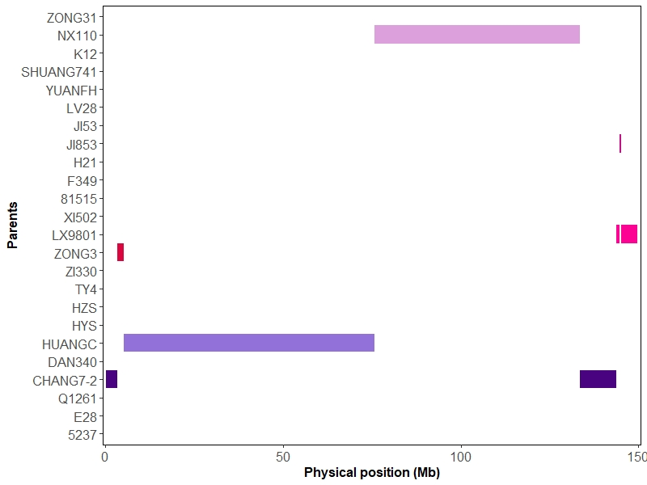

```r
## load example data
data(IBDTestData)

## compute rou from genetic position
rou = IBDTestData$posGenetic
rou = diff(rou)
rou = ifelse(rou<0,0,rou)

## constract IBD map of chr10 for one progeny
IBDRes <- IBDConstruct(snpParents = IBDTestData$snpParents,
markerInfo = IBDTestData$markerInfo,
snpProgeny = IBDTestData$snpProgeny,q = 0.97,G = 9,rou = rou)

## plot
# color
color <- c("#DA053F","#FC0393","#C50F84","#D870D4","#DCA0DC","#4A0380",
           "#9271D9","#0414FB","#2792FC","#4883B2","#2CFFFE","#138B8A",
           "#42B373","#9BFB9C","#84FF2F","#566B32","#FED62D","#FD8A21",
           "#F87E75","#B01D26","#7E0006","#A9A9A9","#FFFE34","#FEBFCB")
names(color) <- 1:24

# parent label
parentInfo <- c("5237","E28","Q1261","CHANG7-2","DAN340","HUANGC","HYS",
                "HZS","TY4","ZI330","ZONG3","LX9801","XI502","81515",
                "F349","H21","JI853","JI53","LV28","YUANFH","SHUANG741",
                "K12","NX110","ZONG31")
names(parentInfo) <- 1:24

# plot
binsPlot(IBDRes,color,parentInfo,24)
```

Figure3 Bins map plot

#### Visualization of overall bins data

Take chromosome-1 and first 200 progeny as an example.

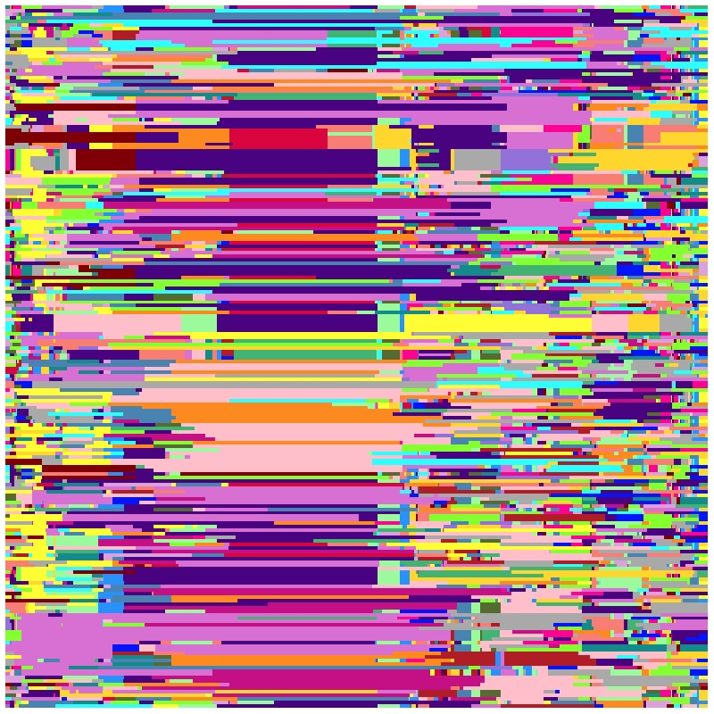

```r
## load data
data(bins)
data(binsInfo)
## color
color <- c("#DA053F","#FC0393","#C50F84","#D870D4","#DCA0DC","#4A0380",
            "#9271D9","#0414FB","#2792FC","#4883B2","#2CFFFE","#138B8A",
            "#42B373","#9BFB9C","#84FF2F","#566B32","#FED62D","#FD8A21",
            "#F87E75","#B01D26","#7E0006","#A9A9A9","#FFFE34","#FEBFCB")

mosaicPlot(bins = bins,binsInfo = binsInfo,chr = 1,resolution = 500,
                  color = color,
                  list = colnames(bins)[1:200])
```

Figure4 Bins mosaic plot

Back to Contents

### References

Endelman, J. B. (2011). Ridge regression and other kernels for genomic selection with R package rrBLUP. *The plant genome*, *4*(3) https://doi.org/10.3835/plantgenome2011.08.0024

Mott, R., Talbot, C. J., Turri, M. G., Collins, A. C., & Flint, J. (2000). A method for fine mapping quantitative trait loci in outbred animal stocks. *Proceedings of the National Academy of Sciences*, *97*(23), 12649-12654. https://doi.org/10.1073/pnas.230304397

Liu H J, Wang X, Xiao Y, et al. (2020) CUBIC: an atlas of genetic architecture promises directed maize improvement[J]. *Genome biology*, *21*(1): 1-17. https://doi.org/10.1186/s13059-020-1930-x

Back to Contents